# Units

In this lesson, we’ll create the unit scenes that represent the crew of the ship. We’ll also code the select and deselect strategy for player interaction.

In the following lessons, we’ll see how to code move orders between rooms for these units. They will also apply bonuses based on the room type the units move in.

They’ll take automatic anti-hazard actions such as putting fires out and repairing breaches. They can also take damage and heal themselves in the medical room.

For now, we’ll focus on the building blocks and player select and deselect implementation.

## The Unit scene

We’ll use the built-in

[figure not shown]

`Path2D` and

[figure not shown]

`PathFollow2D` nodes for unit movement through the ship instead of complicated path-following math.

Make a new scene with a

[figure not shown]

`Path2D` for the root node. Rename it to *Unit* and save it at `res://TacticalSpaceCombat/Ship/Units/Unit.tscn`.

[figure not shown]

`PathFollow2D` is the node that updates the position of children nodes; not

[figure not shown]

`Path2D`. It’s something to keep in mind as we move along with the next steps.

Add the following nodes to the scene tree:

- A

[figure not shown]

  `PathFollow2D`.
  - An

[figure not shown]

    `Area2D` named *AreaUnit*.
    - A

[figure not shown]

      `Sprite`.
    - A

[figure not shown]

      `CollisionShape2D`.

[figure not shown]

In the *Inspector* **turn off** both *Cubic Interp* and *Loop* on the

[figure not shown]

`PathFollow2D` node.

*Cubic Interp* increases the path’s resolution, which helps to get smoother curves at an extra performance cost. As our units will move on a grid, we don’t need it.

The *Loop* makes the path cycle, which we don’t want either as units will always move from their current position to the end of a generated path.

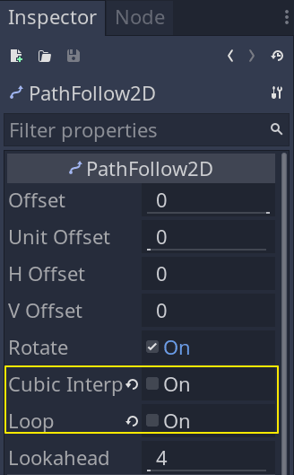

We’ll reference *AreaUnit* later in code for gameplay interactions. We’ll have a separate

[figure not shown]

`Area2D` to cover player-specific interaction; we’ll use *AreaUnit* for detecting overlap with ship objects: rooms, doors, etc.

Select *AreaUnit* and, in the *Node* dock, add it to the `unit` node group. We’ll be using this through the code for filtering detections.

Set the following *Inspector* properties on its child

[figure not shown]

`Sprite` node:

- Assign `res://TacticalSpaceCombat/Assets/Assets.svg` to *Texture*.
- Turn on *Region -> Enabled* and set the *Region -> Rect* to `Rect2(64, 384, 24, 32)`.

You should see the grey unit top-down sprite.

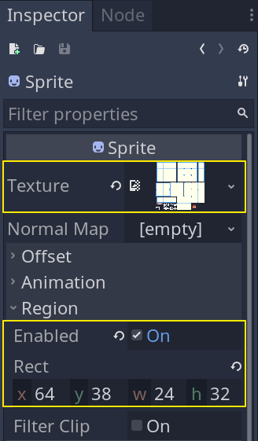

For the

[figure not shown]

`CollisionShape2D`, assign a

[figure not shown]

`RectangleShape2D` to *Shape* and set its *Extents* to `Vector2(8, 8)`. It’s big enough to detect anything in the environment.

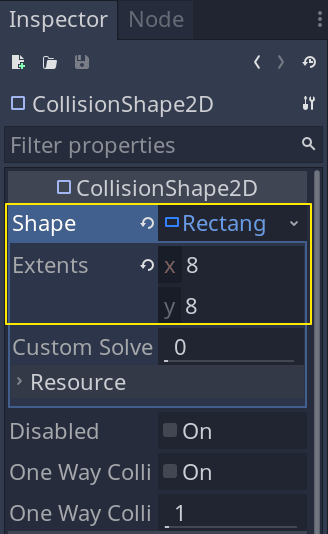

That’s it for the basic unit’s scene structure. We can now start working on unit selection.

## Player and unit interaction

We have to add mouse select and deselect strategies to issue commands to units. We’ll code a rectangular selection that allows you to select units the rectangle overlaps.

Since the AI ship doesn’t require player interaction with the units, we’ll build a player-specific unit scene by inheriting from the `Unit.tscn` scene.

We use this new scene within the player ship, but not the AI ship.

In the *FileSystem* dock, right-click on `Unit.tscn` and select *New Inherited Scene*. A new unsaved scene tab will open, with grayed-out nodes, based on the original `Unit.tscn` scene file. These nodes will be automatically updated when the base scene file changes.

Rename the base root node to *UnitPlayer* to distinguish it from its parent.

Add the following nodes as a child of

[figure not shown]

`PathFollow2D`. Make sure it’s

[figure not shown]

`PathFollow2D` and not

[figure not shown]

`Path2D`!

- An

[figure not shown]

  `Area2D` named *AreaSelect*. We’ll use it to detect when the player tries to select the unit.
  - A

[figure not shown]

    `CollisionShape2D`.

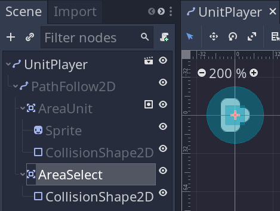

Set the *AreaSelect* node’s *Collision -> Layer* to `UI` (last square) in the *Inspector*. And unset the *Collision -> Mask*.

We want this area to be detected when the player drags a selection rectangle over it, but not for the other gameplay objects.

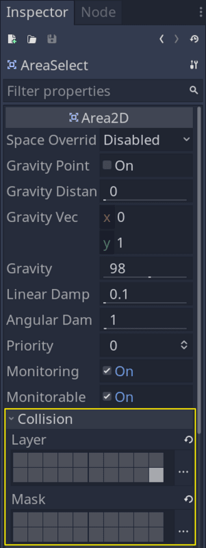

As for the *AreaSelect -> CollisionShape2D* node, assign a *CircleShape2D* to *Shape* and set its *Radius* to `24`. This radius is big enough to make it easy for the player to select the unit.

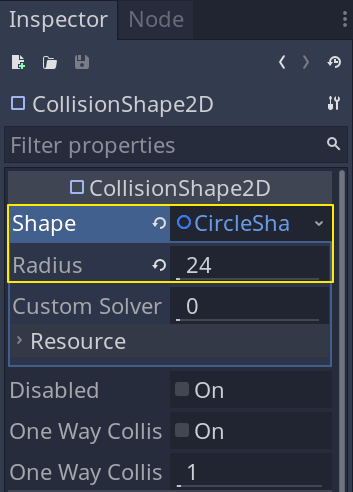

Save this scene at `res://TacticalSpaceCombat/Ship/Units/UnitPlayer.tscn`.

### Preparing for unit selection

Before working on the *Unit* and *UnitPlayer* scenes, we need to prepare the *ShipTemplate* scene.

Add a new

[figure not shown]

`Node2D` named *Units* as a child of *ShipTemplate*. We’ll use it to control and group units, but also to implement selection.

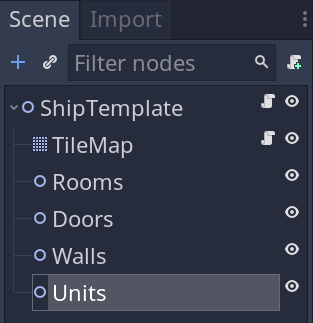

Then, set the *Self Modulate* property on *Units* to `#9b3ca370` (`#3ca370` with lower alpha value) in the *Inspector*.

This is a semi-transparent green color that we’ll use to visualize the rectangular selection area and what’s underneath it.

To draw the selection, we’ll rely on the built-in virtual `_draw()` function.

We use *Self Modulate* rather than *Module* so the child nodes will not change color.

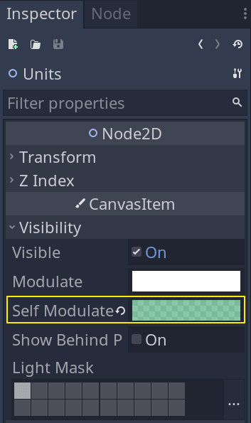

### Coding selection and deselection

We want to attach a script to *Units* to code the select and deselect strategies.

But we want to do so only for *ShipPlayer*, as only the player should be able to do these operations.

Now that we added the node to *ShipTemplate*, open `ShipPlayer.tscn`.

As the *ShipPlayer* inherits from the *ShipTemplate*, you’ll notice it now also has the *Units* node.

We can add a script to it that only attaches to *ShipPlayer*’s *Units*.

Attach a script to the *Units* node and save it in `res://TacticalSpaceCombat/Ship/Units.gd`.

We start by defining a constant and a property for the selection shape we’ll draw.

```
extends Node2D

## Default value for the `_polygon` variable to reset to when we
## stop the selection process.
const DEFAULT_POLYGON := PoolVector2Array([Vector2.ZERO, Vector2.ZERO, Vector2.ZERO, Vector2.ZERO])

## If `true`, the player has an active selection.
var _is_selecting := false
## Stores the four vertices for the selection rectangle we'll draw on-screen.
var _polygon := DEFAULT_POLYGON


# Draws our rectangle using colors from the array passed as the second argument.
# Here, we use only one color: `self_modulate`.
func _draw() -> void:
    draw_polygon(_polygon, [self_modulate])
```

We’re using a polygon to create a rectangular shape instead of the built-in

[figure not shown]

`Rect2`. That’s because, for a polygon, we need to provide four vertices.

In contrast,

[figure not shown]

`Rect2` uses a start position and a size (width and height). But in our case, it’s simpler to keep track of the four corner points instead.

We do this in the `_input()` function next:

[output not shown]

We usually use the `_unhandled_input()` virtual function for gameplay input because it allows the UI to intercept and block events from propagating to the gameplay world.

In our case, we want `_input()` instead so mouse clicks will get captured even if we press on the UI elements.

You’ll better understand why we need this in the next lesson, when we code unit selection using the UI.

You can learn more about input virtual functions in the documentation: [How input events work](https://docs.godotengine.org/en/stable/tutorials/inputs/inputevent.html#how-does-it-work).

If you now run the *ShipPlayer* scene, you’ll be able to press `LMB` & drag to create a selection rectangle like in the image below.

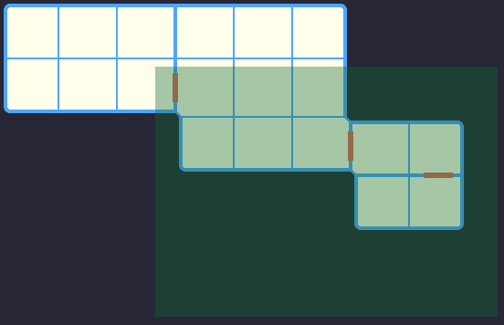

*Note* that this code works for a single unit selection on a basic `LMB` press as well.

We technically construct a zero-sized rectangle with the mouse cursor position, and that’s enough for selection to trigger on a single unit.

### Updating player units scene for select and deselect

Next, let’s implement the player select and deselect feedback on *UnitPlayer*.

Open the `Unit.tscn` scene and add a script to its root node with the following contents:

```
class_name Unit
extends Path2D

# We group all possible unit colors here, even if the base unit doesn't have a
# selected state.
const COLORS := {"default": Color("323e4f"), "selected": Color("3ca370")}

# We'll use this reference in the UnitPlayer in a second.
onready var area_unit: Area2D = $PathFollow2D/AreaUnit


func _ready() -> void:
    area_unit.modulate = COLORS.default
```

Open the *UnitPlayer* scene and extend the script on the root node. We’re going to make a class dedicated to player-controlled units, with selection support.

```
extends Unit

## `Units.gd` manages this property. That's  where we query Godot for the selected
## units under a rectangular area activated by `LMB` & dragging the mouse.
var is_selected: bool setget set_is_selected

onready var area_select: Area2D = $PathFollow2D/AreaSelect


func _ready() -> void:
    # Instead of assigning `false` on declaration we assign it here,
    # using `self.` to trigger the call to the setter function
    self.is_selected = false


func set_is_selected(value: bool) -> void:
    # We keep track of selected units using this group name
    var group := "selected-unit"

    is_selected = value
    if is_selected:
        area_unit.modulate = COLORS.selected
        add_to_group(group)
    else:
        area_unit.modulate = COLORS.default
        if is_in_group(group):
            remove_from_group(group)
```

In the `set_is_selected()` function depending on the value of `is_selected`, we assign an appropriate color and update the `selected-unit` node group.

We’ll use the `selected-unit` group name to access units marked as selected in different parts in our code base.

The color is for feedback to the player: to see which units they selected at any given time.

We defined the `COLOR` constant in the parent `Unit` class.

## Checking out the progress

Open the `ShipPlayer.tscn` scene file. We’ll update it by adding *UnitPlayer* nodes under *Units* to test our progress.

Instantiate `UnitPlayer.tscn` a few times by dragging the file over the *Units* node.

We need to turn on *Editable Children* from the `RMB` menu on the *UnitPlayer* nodes to manipulate the location of

[figure not shown]

`PathFollow2D`.

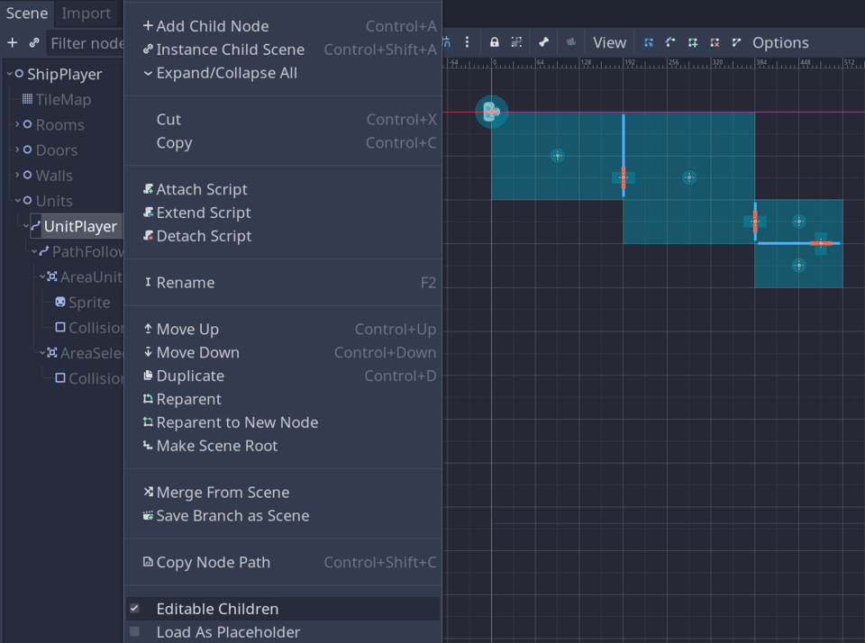

To position the units throughout the ship, select their

[figure not shown]

`PathFollow2D` child in the *Scene* dock and in the viewport, use `ALT`+`LMB` to move the node with the *Select Mode* (`Q`) active. Make sure you move the

[figure not shown]

`PathFollow2D` node and not

[figure not shown]

`Path2D`! This is crucial and could break the game if done improperly.

We only need to do this for testing. The

[figure not shown]

`PathFollow2D` will save us work later on to have units walk around the ship.

*Note* that on some operating systems, the `ALT`+`LMB` combination might move the application window instead. These are system-dependent settings that have nothing to do with Godot. You could use `W` as a shortcut for the move tool or change the behavior of your `ALT` key.

Ensure to place the units in the middle of the `64` x `64` tiles like in the image below.

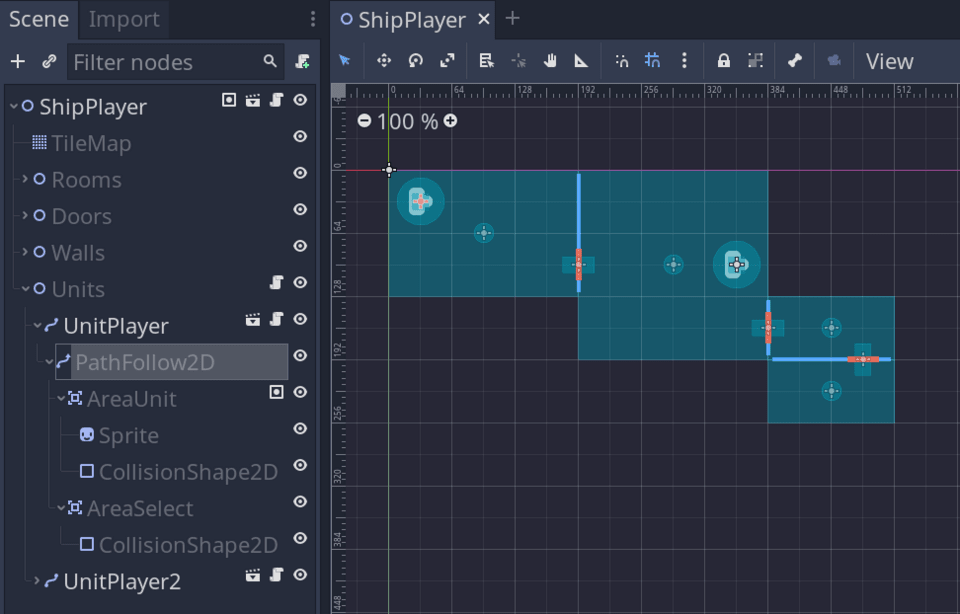

Running the *ShipPlayer* scene now, you should be able to select and deselect the *UnitPlayer* game objects either by pressing `LMB` on them or by dragging a rectangular selection box like in the image below.

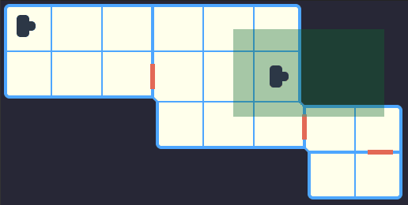

Upon releasing the click, units overlapping with the rectangle should turn green to indicate they’re selected.

## Conclusion

In this lesson, we prepared the necessary building blocks for ship units. We implemented select and deselect strategies with the help of Godot’s on-demand physics querying.

In the next lesson, we’ll cover player unit UI feedback and interactions. It’s the last detail before covering unit movement from room to room.

Units will move without overlapping in the destination tile. They’ll also traverse the smallest distance when rooms are inter-connected with more than one door. We’ll cover all this after we take care of the player UI.

## Code reference

`res://TacticalSpaceCombat/Ship/Units/Unit.gd`:

```
class_name Unit
extends Path2D

const COLORS := {"default": Color("323e4f"), "selected": Color("3ca370")}

onready var area_unit: Area2D = $PathFollow2D/AreaUnit


func _ready() -> void:
    area_unit.modulate = COLORS.default
```

`TacticalSpaceCombat/Ship/Units/UnitPlayer.gd`:

```
extends Unit

var is_selected: bool setget set_is_selected

onready var area_select: Area2D = $PathFollow2D/AreaSelect


func _ready() -> void:
    self.is_selected = false


func set_is_selected(value: bool) -> void:
    var group := "selected-unit"

    is_selected = value
    if is_selected:
        area_unit.modulate = COLORS.selected
        add_to_group(group)
    else:
        area_unit.modulate = COLORS.default
        if is_in_group(group):
            remove_from_group(group)
```

`res://TacticalSpaceCombat/Ship/Units.gd`:

```
extends Node2D

const DEFAULT_POLYGON := PoolVector2Array([Vector2.ZERO, Vector2.ZERO, Vector2.ZERO, Vector2.ZERO])

var _is_selecting := false
var _polygon := DEFAULT_POLYGON


func _input(event: InputEvent) -> void:
    if not event is InputEventMouse:
        return

    var mouse_position := get_local_mouse_position()
    if event.is_action_pressed("left_click"):
        _is_selecting = true

        for index in range(_polygon.size()):
            _polygon[index] = mouse_position

        for unit in get_children():
            unit.is_selected = false

    elif _is_selecting and event is InputEventMouseMotion:
        _polygon[1] = Vector2(mouse_position.x, _polygon[0].y)
        _polygon[2] = mouse_position
        _polygon[3] = Vector2(_polygon[0].x, mouse_position.y)

    elif event.is_action_released("left_click"):
        select_units()

        _is_selecting = false
        _polygon = DEFAULT_POLYGON

    update()


func _draw() -> void:
    draw_polygon(_polygon, [self_modulate])


func select_units() -> void:
    var query := Physics2DShapeQueryParameters.new()
    var shape := ConvexPolygonShape2D.new()
    shape.points = _polygon

    query.set_shape(shape)
    query.transform = global_transform
    query.collide_with_bodies = false
    query.collide_with_areas = true
    query.collision_layer = Global.Layers.UI

    for dict in get_world_2d().direct_space_state.intersect_shape(query):
        dict.collider.owner.is_selected = true
```